# Linear Regression: Model Specification, Comparison, and Interpretation

A worked example using the Attitude dataset

Author

Graduate Statistics

Published

November 6, 2026

# 1 Purpose

This lab examines the relationships between overall workplace ratings and three workplace attitude variables: complaint handling, learning opportunities, and pay increases.

The analysis uses the built-in `attitude` dataset in R, which contains information from 30 departments. The main objective is to specify, estimate, and compare multiple linear regression models to evaluate whether these workplace attitude variables explain variation in overall workplace ratings.

The analysis follows a reproducible workflow, including data exploration, model specification, nested-model comparisons, regression diagnostics, model selection, and interpretation of regression coefficients.

# 2 Configure the project and load packages

## 2.1 Load required packages

The following packages are required for data manipulation, visualization, regression analysis, and reporting.

Install missing packages once in the R Console if necessary. Package installation is not required when rendering this document.

```r
# Load required packages
library(dplyr)
library(tidyr)
library(ggplot2)
library(broom)
library(performance)
library(gt)
```

## 2.2 Load the dataset

The built-in `attitude` dataset contains department-level summaries of employee attitudes. Each observation represents one department rather than an individual employee.

For this analysis, four numerical variables are selected:

| Variable | Description | Role |
| --- | --- | --- |
| rating | Overall workplace rating | Outcome |
| complaints | Handling of employee complaints | Predictor |
| learning | Opportunities to learn | Predictor |
| raises | Pay increases | Predictor |

```r
# Load the dataset
data("attitude", package = "datasets")

# Create the analysis dataset
attitude_data <- datasets::attitude

dat <- attitude_data %>%
  select(rating, complaints, learning, raises) %>%
  drop_na()

# Number of observations
n <- nrow(dat)

# Inspect the first observations
head(dat)
```

```
  rating complaints learning raises
1     43         51       39     61
2     63         64       54     63
3     71         70       69     76
4     61         63       47     54
5     81         78       66     71
6     43         55       44     54
```

Inspect the structure of the analysis dataset:

```r
str(dat)
```

```
'data.frame':   30 obs. of  4 variables:
 $ rating    : num  43 63 71 61 81 43 58 71 72 67 ...
 $ complaints: num  51 64 70 63 78 55 67 75 82 61 ...
 $ learning  : num  39 54 69 47 66 44 56 55 67 47 ...
 $ raises    : num  61 63 76 54 71 54 66 70 71 62 ...
```

The analysis dataset contains 30 department-level observations and four numerical variables. The outcome variable is `rating`, representing overall workplace ratings. The three predictors are `complaints`, `learning`, and `raises`.

# 3 Explore the data

## 3.1 Descriptive statistics

Before fitting regression models, descriptive statistics are calculated to examine the distributions and ranges of the four analysis variables.

The following table reports the mean, standard deviation, minimum, and maximum for each variable.

```r
descriptive_table <- dat %>%
  pivot_longer(
    cols = everything(),
    names_to = "Variable",
    values_to = "Value"
  ) %>%
  group_by(Variable) %>%
  summarise(
    Mean = mean(Value),
    SD = sd(Value),
    Minimum = min(Value),
    Maximum = max(Value),
    .groups = "drop"
  )

descriptive_table %>%
  gt() %>%
  fmt_number(
    columns = c(Mean, SD, Minimum, Maximum),
    decimals = 2
  ) %>%
  cols_label(
    Variable = "Variable",
    Mean = "Mean",
    SD = "Standard Deviation",
    Minimum = "Minimum",
    Maximum = "Maximum"
  ) %>%
  tab_header(
    title = "Descriptive Statistics",
    subtitle = "Attitude dataset: 30 departments"
  )
```

Descriptive Statistics

Attitude dataset: 30 departments

| Variable | Mean | Standard Deviation | Minimum | Maximum |
| --- | --- | --- | --- | --- |
| complaints | 66.60 | 13.31 | 37.00 | 90.00 |
| learning | 56.37 | 11.74 | 34.00 | 75.00 |
| raises | 64.63 | 10.40 | 43.00 | 88.00 |
| rating | 64.63 | 12.17 | 40.00 | 85.00 |

## 3.2 Distribution of overall workplace ratings

The histogram with an overlaid density curve illustrates the distribution of overall workplace ratings across departments.

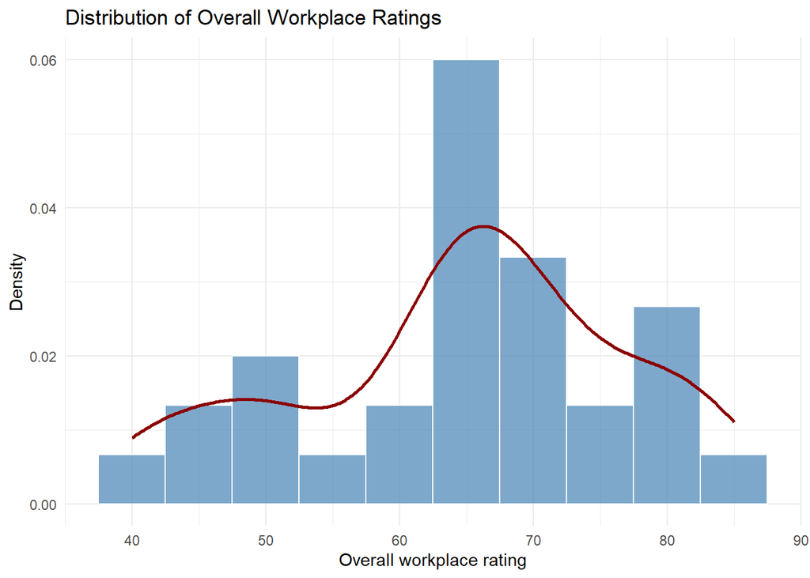

```r
ggplot(dat, aes(x = rating)) +
  geom_histogram(
    aes(y = after_stat(density)),
    bins = 10,
    fill = "steelblue",
    color = "white",
    alpha = 0.7
  ) +
  geom_density(
    color = "darkred",
    linewidth = 1
  ) +
  labs(
    title = "Distribution of Overall Workplace Ratings",
    x = "Overall workplace rating",
    y = "Density"
  ) +
  theme_minimal()
```

## 3.3 Relationships between predictors and overall ratings

Scatterplots are used to examine the relationships between overall workplace ratings and each predictor. Fitted linear regression lines and confidence intervals are included to assess the direction and approximate linearity of these relationships.

### 3.3.1 Rating and complaints

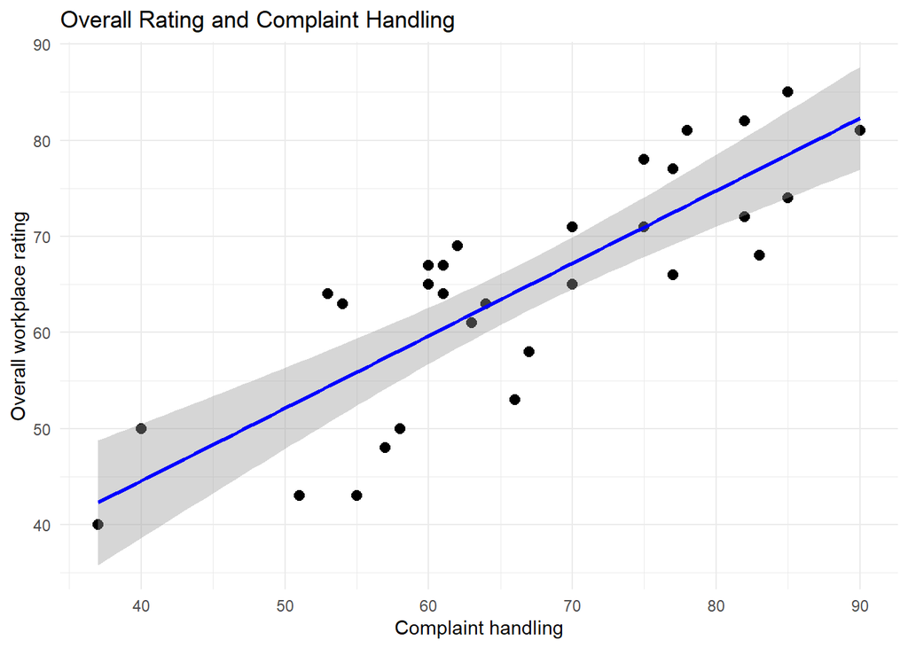

```r
ggplot(dat, aes(x = complaints, y = rating)) +
  geom_point(size = 2.5) +
  geom_smooth(
    method = "lm",
    se = TRUE,
    color = "blue"
  ) +
  labs(
    title = "Overall Rating and Complaint Handling",
    x = "Complaint handling",
    y = "Overall workplace rating"
  ) +
  theme_minimal()
```

### 3.3.2 Rating and learning

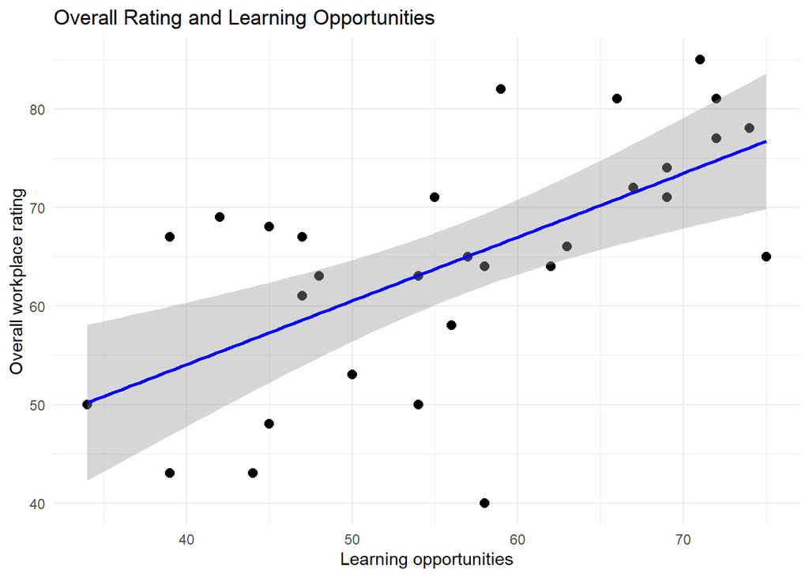

```r
ggplot(dat, aes(x = learning, y = rating)) +
  geom_point(size = 2.5) +
  geom_smooth(
    method = "lm",
    se = TRUE,
    color = "blue"
  ) +
  labs(
    title = "Overall Rating and Learning Opportunities",
    x = "Learning opportunities",
    y = "Overall workplace rating"
  ) +
  theme_minimal()
```

### 3.3.3 Rating and raises

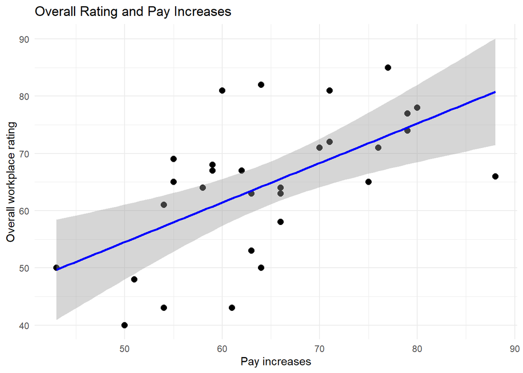

```r
ggplot(dat, aes(x = raises, y = rating)) +
  geom_point(size = 2.5) +
  geom_smooth(
    method = "lm",
    se = TRUE,
    color = "blue"
  ) +
  labs(
    title = "Overall Rating and Pay Increases",
    x = "Pay increases",
    y = "Overall workplace rating"
  ) +
  theme_minimal()
```

## 3.4 Correlation analysis

The correlation matrix provides an additional summary of the linear associations among the four variables.

```r
correlation_matrix <- cor(dat)

round(correlation_matrix, 3)
```

```
           rating complaints learning raises
rating      1.000      0.825    0.624  0.590
complaints  0.825      1.000    0.597  0.669
learning    0.624      0.597    1.000  0.640
raises      0.590      0.669    0.640  1.000
```

The following figure visualizes the correlation coefficients:

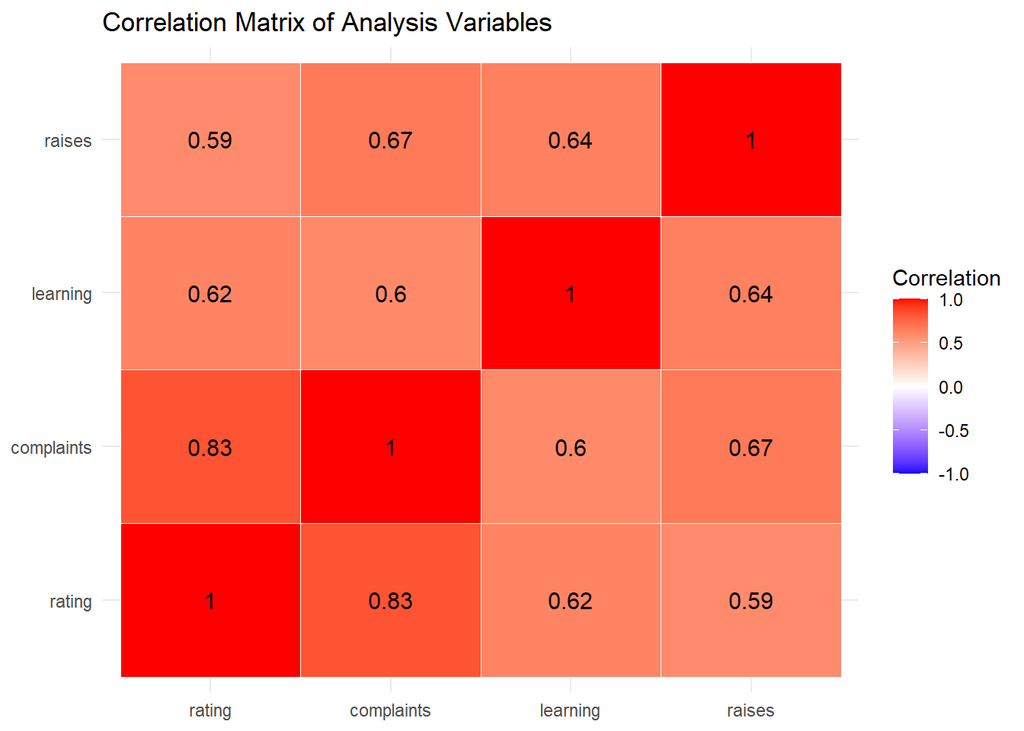

```r
correlation_long <- as.data.frame(
  as.table(correlation_matrix)
)

ggplot(
  correlation_long,
  aes(x = Var1, y = Var2, fill = Freq)
) +
  geom_tile(color = "white") +
  geom_text(
    aes(label = round(Freq, 2)),
    size = 4
  ) +
  scale_fill_gradient2(
    low = "blue",
    mid = "white",
    high = "red",
    midpoint = 0,
    limits = c(-1, 1)
  ) +
  labs(
    title = "Correlation Matrix of Analysis Variables",
    x = NULL,
    y = NULL,
    fill = "Correlation"
  ) +
  theme_minimal()
```

## 3.5 Exploratory findings

The exploratory analysis includes 30 departments and four numerical variables.

The correlations between overall workplace ratings and the three predictors are calculated below:

```r
rating_correlations <- correlation_matrix[
  "rating",
  c("complaints", "learning", "raises")
]

rating_correlations
```

```
complaints   learning     raises
 0.8254176  0.6236782  0.5901390
```

The results indicate positive associations between overall workplace ratings and the three predictors. The strongest correlation can be identified using the following code:

```r
strongest_predictor <- names(which.max(rating_correlations))

strongest_correlation <- max(rating_correlations)

strongest_predictor
```

```
[1] "complaints"
```

```r
strongest_correlation
```

```
[1] 0.8254176
```

# 4 Specify competing regression models

## 4.1 Develop your predictions

I expect all three predictors to be positively associated with overall workplace ratings.

First, effective handling of employee complaints may contribute to a more positive workplace environment by addressing employees’ concerns and improving their perceptions of organizational fairness and support. Therefore, departments with higher complaint-handling scores are expected to have higher overall workplace ratings.

Second, opportunities for learning and professional development may improve employees’ skills, engagement, and job satisfaction. I expect learning to explain additional variation in overall workplace ratings beyond what is explained by complaint handling alone.

Finally, pay increases may contribute to employees’ perceptions of being valued and fairly compensated. Therefore, I expect raises to potentially explain further variation in overall workplace ratings after accounting for both complaint handling and learning.

However, the additional contribution of each predictor will need to be evaluated using regression models.

## 4.2 Specify four nested models

Four nested linear regression models are estimated. Each successive model includes all predictors from the preceding model.

| Model | Predictors | Purpose |
| --- | --- | --- |
| M0: Null | Intercept only | Establish a baseline |
| M1: Complaints | complaints | Evaluate complaint handling |
| M2: Complaints + Learning | complaints, learning | Evaluate the additional contribution of learning |
| M3: Expanded | complaints, learning, raises | Evaluate the additional contribution of pay increases |

```r
# Estimate four nested regression models

M0 <- lm(rating ~ 1, data = dat)

M1 <- lm(rating ~ complaints, data = dat)

M2 <- lm(rating ~ complaints + learning, data = dat)

M3 <- lm(rating ~ complaints + learning + raises, data = dat)
```

## 4.3 Explore your fitted models

The fitted models are examined to assess the associations between the predictors and overall workplace ratings.

```r
# Explore your fitted models

# Store the four models in a list

models <- list(
  M0 = M0,
  M1 = M1,
  M2 = M2,
  M3 = M3
)

# Display model summaries
summary(M0)
```

```
Call:
lm(formula = rating ~ 1, data = dat)

Residuals:
     Min       1Q   Median       3Q      Max
-24.6333  -5.8833   0.8667   7.1167  20.3667

Coefficients:
            Estimate Std. Error t value Pr(>|t|)
(Intercept)   64.633      2.222   29.08   <2e-16 ***
---
Signif. codes:  0 '***' 0.001 '**' 0.01 '*' 0.05 '.' 0.1 ' ' 1

Residual standard error: 12.17 on 29 degrees of freedom
```

```r
summary(M1)
```

```
Call:
lm(formula = rating ~ complaints, data = dat)

Residuals:
     Min       1Q   Median       3Q      Max
-12.8799  -5.9905   0.1783   6.2978   9.6294

Coefficients:
            Estimate Std. Error t value Pr(>|t|)
(Intercept) 14.37632    6.61999   2.172   0.0385 *
complaints   0.75461    0.09753   7.737 1.99e-08 ***
---
Signif. codes:  0 '***' 0.001 '**' 0.01 '*' 0.05 '.' 0.1 ' ' 1

Residual standard error: 6.993 on 28 degrees of freedom
Multiple R-squared:  0.6813,    Adjusted R-squared:  0.6699
F-statistic: 59.86 on 1 and 28 DF,  p-value: 1.988e-08
```

```r
summary(M2)
```

```
Call:
lm(formula = rating ~ complaints + learning, data = dat)

Residuals:
     Min       1Q   Median       3Q      Max
-11.5568  -5.7331   0.6701   6.5341  10.3610

Coefficients:
            Estimate Std. Error t value Pr(>|t|)
(Intercept)   9.8709     7.0612   1.398    0.174
complaints    0.6435     0.1185   5.432 9.57e-06 ***
learning      0.2112     0.1344   1.571    0.128
---
Signif. codes:  0 '***' 0.001 '**' 0.01 '*' 0.05 '.' 0.1 ' ' 1

Residual standard error: 6.817 on 27 degrees of freedom
Multiple R-squared:  0.708, Adjusted R-squared:  0.6864
F-statistic: 32.74 on 2 and 27 DF,  p-value: 6.058e-08
```

```r
summary(M3)
```

```
Call:
lm(formula = rating ~ complaints + learning + raises, data = dat)

Residuals:
     Min       1Q   Median       3Q      Max
-11.6282  -5.8107   0.5115   6.3946  10.3509

Coefficients:
            Estimate Std. Error t value Pr(>|t|)
(Intercept) 10.52260    8.30481   1.267    0.216
complaints   0.65349    0.13637   4.792 5.82e-05 ***
learning     0.22069    0.14967   1.475    0.152
raises      -0.02864    0.18245  -0.157    0.876
---
Signif. codes:  0 '***' 0.001 '**' 0.01 '*' 0.05 '.' 0.1 ' ' 1

Residual standard error: 6.943 on 26 degrees of freedom
Multiple R-squared:  0.7083,    Adjusted R-squared:  0.6746
F-statistic: 21.04 on 3 and 26 DF,  p-value: 3.957e-07
```

```r
# Table 1: Model coefficients
coefficient_table <- dplyr::bind_rows(
  lapply(names(models), function(model_name) {
    broom::tidy(models[[model_name]]) %>%
      dplyr::mutate(Model = model_name)
  })
) %>%
  dplyr::select(
    Model, term, estimate, std.error, statistic, p.value
  )

coefficient_table %>%
  gt() %>%
  fmt_number(
    columns = c(estimate, std.error, statistic),
    decimals = 3
  ) %>%
  fmt_number(
    columns = p.value,
    decimals = 4
  ) %>%
  cols_label(
    Model = "Model",
    term = "Predictor",
    estimate = "Estimate",
    std.error = "Standard Error",
    statistic = "t-value",
    p.value = "P-value"
  ) %>%
  tab_header(
    title = "Regression Coefficients",
    subtitle = "Coefficient estimates across the four nested models"
  )
```

Regression Coefficients

Coefficient estimates across the four nested models

| Model | Predictor | Estimate | Standard Error | t-value | P-value |
| --- | --- | --- | --- | --- | --- |
| M0 | (Intercept) | 64.633 | 2.222 | 29.083 | 0.0000 |
| M1 | (Intercept) | 14.376 | 6.620 | 2.172 | 0.0385 |
| M1 | complaints | 0.755 | 0.098 | 7.737 | 0.0000 |
| M2 | (Intercept) | 9.871 | 7.061 | 1.398 | 0.1735 |
| M2 | complaints | 0.644 | 0.118 | 5.432 | 0.0000 |
| M2 | learning | 0.211 | 0.134 | 1.571 | 0.1278 |
| M3 | (Intercept) | 10.523 | 8.305 | 1.267 | 0.2164 |
| M3 | complaints | 0.653 | 0.136 | 4.792 | 0.0001 |
| M3 | learning | 0.221 | 0.150 | 1.475 | 0.1523 |
| M3 | raises | −0.029 | 0.182 | −0.157 | 0.8765 |

```r
# Table 2: Overall model performance
model_fit_table <- dplyr::bind_rows(
  lapply(names(models), function(model_name) {
    broom::glance(models[[model_name]]) %>%
      dplyr::mutate(Model = model_name)
  })
) %>%
  dplyr::select(
    Model, nobs, df.residual, r.squared,
    adj.r.squared, sigma, statistic, p.value
  )

model_fit_table %>%
  gt() %>%
  fmt_number(
    columns = c(nobs, df.residual),
    decimals = 0
  ) %>%
  fmt_number(
    columns = c(
      r.squared, adj.r.squared,
      sigma, statistic, p.value
    ),
    decimals = 4
  ) %>%
  cols_label(
    Model = "Model",
    nobs = "N",
    df.residual = "Residual df",
    r.squared = "R²",
    adj.r.squared = "Adjusted R²",
    sigma = "Residual SD",
    statistic = "F-statistic",
    p.value = "Model P-value"
  ) %>%
  tab_header(
    title = "Overall Model Performance",
    subtitle = "Comparison of the four nested regression models"
  )
```

Overall Model Performance

Comparison of the four nested regression models

| Model | N | Residual df | R² | Adjusted R² | Residual SD | F-statistic | Model P-value |
| --- | --- | --- | --- | --- | --- | --- | --- |
| M0 | 30 | 29 | 0.0000 | 0.0000 | 12.1726 | NA | NA |
| M1 | 30 | 28 | 0.6813 | 0.6699 | 6.9933 | 59.8608 | 0.0000 |
| M2 | 30 | 27 | 0.7080 | 0.6864 | 6.8168 | 32.7353 | 0.0000 |
| M3 | 30 | 26 | 0.7083 | 0.6746 | 6.9433 | 21.0434 | 0.0000 |

The coefficient for complaints represents its association with overall workplace ratings. In Model 1, this coefficient reflects the association between complaints and ratings without adjusting for other predictors. In Model 2, it represents the association after controlling for learning opportunities. In Model 3, it represents the association after controlling for both learning opportunities and pay increases. Comparing the coefficient estimates across these models helps determine whether the association between complaint handling and overall workplace ratings changes when additional predictors are included.